# Lab-3

Author

Brian Kwon

# Problem 1:

Plot probability density histograms for these discrete distributions (hint: use the d…() function).

```r
library("extraDistr")
```

1. Binomial Distribution

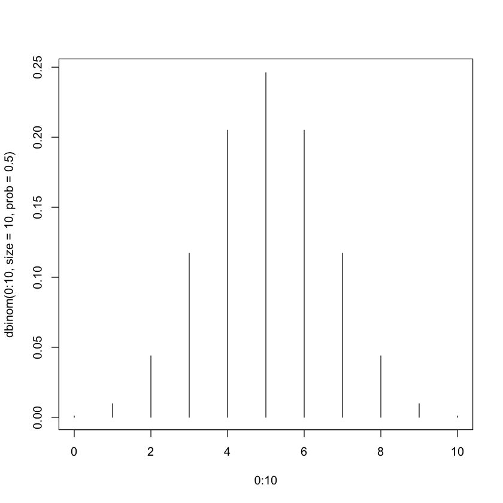

```r
plot(0:10,dbinom(0:10,size=10,prob=.5),type="h")
```

2. Discrete uniform

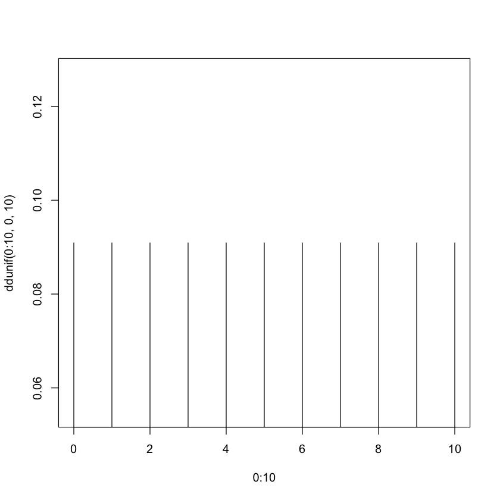

```r
plot(0:10,ddunif(0:10,0,10),type="h")
```

3. Bernoulli

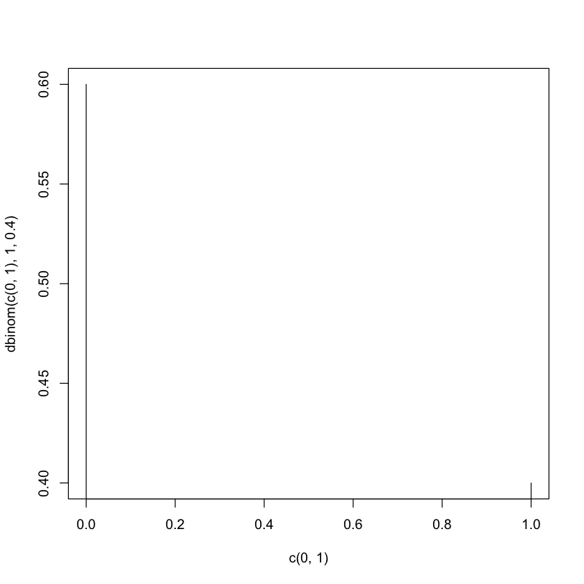

```r
plot(c(0,1),dbinom(c(0,1),1,0.4),type="h")
```

4. Poisson

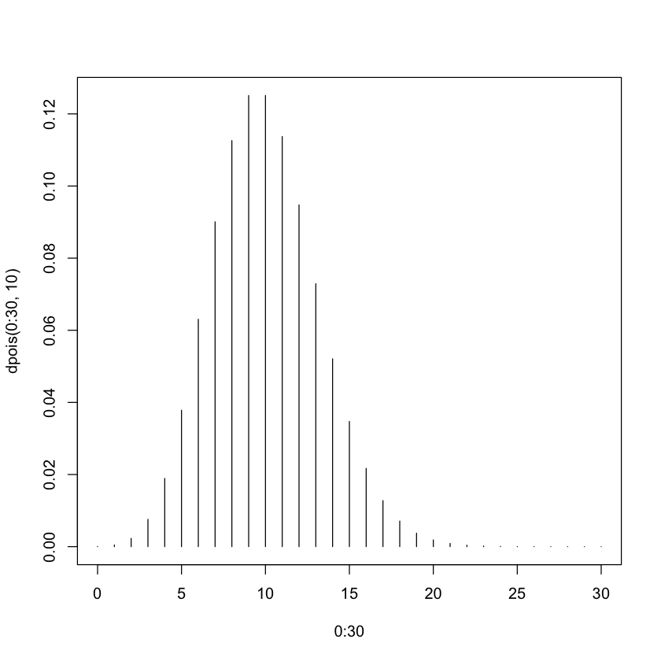

```r
plot(0:30, dpois(0:30, 10), type = 'h')
```

5. Geometric

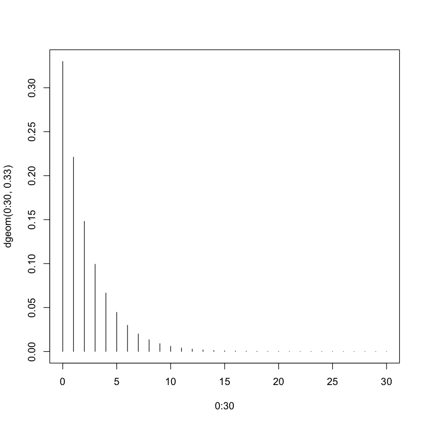

```r
plot(0:30, dgeom(0:30,0.33), type = 'h')
```

6. Hyper-geometric

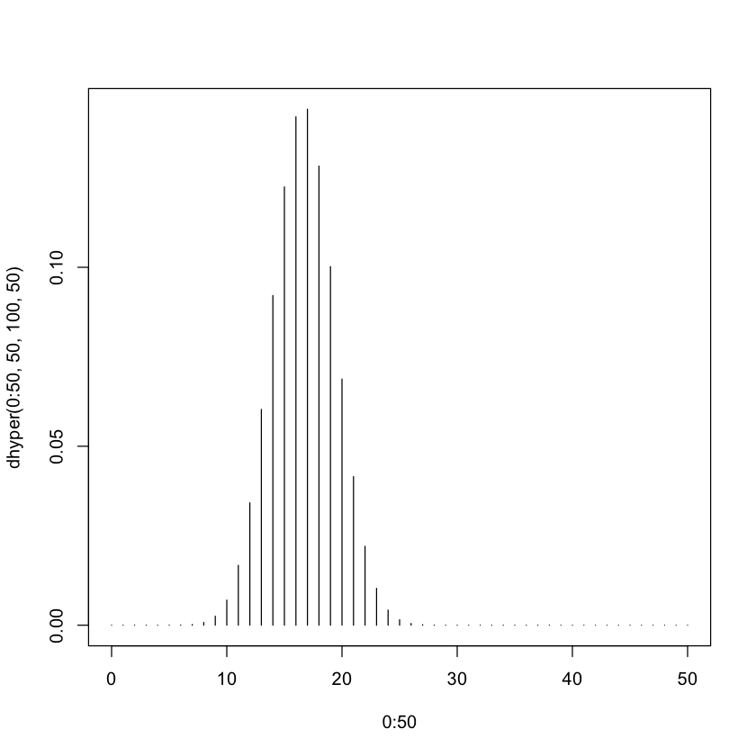

```r
plot(0:50,dhyper(0:50,50,100,50), type="h")
```

7. Negative binomial

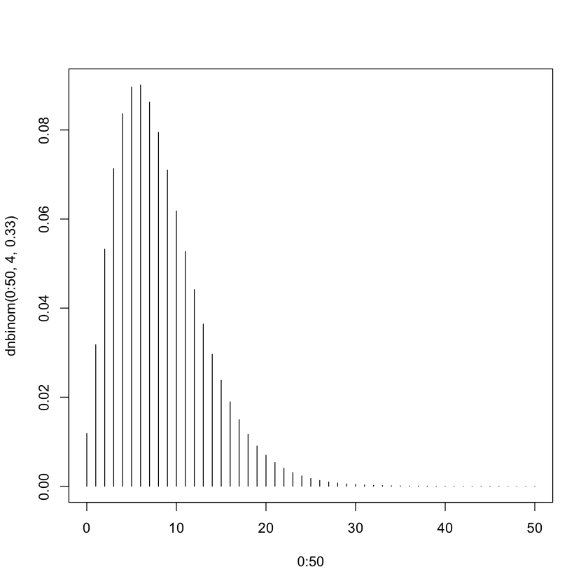

```r
plot(0:50, dnbinom(0:50,4,0.33), type = 'h')
```

# Problem 2.

Suppose there are fifteen multiple choice questions in `DSAN-5100` midterm test. Each question has four possible answers, and only one of them is correct. Find the probability of having four or less correct answers if a student attempts to answer every question at random.

1. Compute the probability of having exactly 4 correct answers by random attempts using *dbinom()* and *pbinom()*.

```r
dbinom(4,15,0.25)
```

0.225199065171182

```r
pbinom(4,15,0.25)-pbinom(3,15,0.25)
```

0.225199065171182

2. Find the the probability of having four or less correct answers by random attempts using dbinom().

```r
sum(dbinom(0:4,15,0.25))
```

0.686485941521823

3. Compute the above probability(part-b) using pbinom().

```r
pbinom(4,15,0.25)
```

0.686485941521823

# Problem 3:

`use r to find the probability`

1. Assume an insurance company receives 3 motor vehicle insurance claims per week. What is the probability that they recieve 11 or fewer claims during a month?

$$P(X\le11)?$$

```r
ppois(11,12)
```

0.461597333063618

2. While you are at the Georgetown library terrace, you notice that airplanes fly at an average rate of 1 every 4 hours. What is the probability that you will see at least one plane in the next hour?

```r
1-dpois(0,1/4)
```

0.221199216928595

# Problem 4:

`Try this example with _..nbinom()_`

(This relates to Problem-1 in Lab-1 Assignment)

Mike had the first three successes in trials 6, 8, and 9. He had six failures until he reached three successes.

Do you think Mike has *success probability p = 0.5 or better?* Can a simulation give an answer?Let’s try.

1. If Mike’s success probability is p = 0.5 What is the probability that he will obtain these 3 successes?.

```r
dnbinom(6,3,0.5)
```

0.0546875

2. Run many simulations (say 10,000) with this success probability to find the same probability $P(X=6)?$ *Hint: Use rnbinom()*

```r
mean(rnbinom(10000,3,0.5)==6)
```

0.0561

3. If Mike’s success probability were 0.5 or better, he would not need a lot of attempts. Find the probability that three successes were reached after 9 tosses or later by somebody with success probability 0.5. $P(X\ge6)$
1. Calculate the probabiliy using both *dnbinom()* and *pnbinom()*.

```r
1 - sum(dnbinom(0:5,3,0.5))
```

0.14453125

```r
1 - pnbinom(5,3,0.5)
```

0.14453125

2. Calculate this probability using a Simulation(10,000)

```r
mean(rnbinom(10000,3,0.5)>=6)
```

0.1477

3. Is this probability (part b) the same as you got from “myattempts”: Lab 1 Assignment Problem 1 part 3?

```r
mytoss = function(p){
  u = runif(1)
  x = as.numeric(u < p)
  return(x)
}

myattempts = function(p){
  counter = 1
  while (mytoss(p) == 0){ counter = counter + 1 }
  return(counter)
}

sum(replicate(10000,sum(replicate(3,myattempts(0.5))))>=9)/10000
```

0.1494

The probability from part b is very similar from Lab 1 Assignment.